# Lab 4 - Checkpoint 1

Arnaldo Gualberto

20/05/2017

O objetivo do checkpoint 1 do Lab 4 é analisar uma amostra de dados da atividade global do github. Esses dados contém a quantidade de usuários que editaram arquivos de diferentes extensões durante 2016 e 2017. Para este relatório, deve-se selecionar duas linguagens e responder as seguintes perguntas:

- Para cada uma delas, há uma diferença significativa na sua popularidade durante a semana e durante o fim de semana?
- Existe uma diferença significativa na variação da popularidade das duas quando você compara o quanto a popularidade de cada uma varia durante os dias da semana?

# 0. Includes e Settings

```r
library(dplyr, warn.conflicts = FALSE)
library(ggplot2)
library(knitr)
library(lubridate, warn.conflicts = FALSE)
library(readr)
library(resample)
source("multiplot.R")

# Coloca todos os titulos dos gráficos centralizados
theme_update(plot.title = element_text(hjust=0.5))
```

# 1. Carregamento e limpeza dos dados

Primeiramente, vou carregar os dados e alterar o nome de suas colunas para facilitar o entendimento:

```r
dados_github <- read_csv("data/github-data.csv")
names(dados_github) <- c("extensao", "dia", "mes", "ano", "usuarios")
glimpse(dados_github)
```

```
## Observations: 13,802
## Variables: 5
## $ extensao <chr> "md", "md", "md", "md", "md", "md", "md", "md", "md",...
## $ dia      <int> 18, 17, 27, 16, 26, 21, 4, 22, 23, 1, 12, 3, 2, 21, 2...
## $ mes      <int> 2, 2, 1, 2, 1, 3, 2, 2, 2, 2, 4, 2, 2, 2, 4, 3, 4, 1,...
## $ ano      <int> 2016, 2016, 2016, 2016, 2016, 2017, 2016, 2016, 2016,...
## $ usuarios <int> 10279, 10208, 10118, 10045, 10020, 10015, 9991, 9962,...
```

Agora, vou criar duas novas colunas: uma com a data por completo e outra com o dia da semana correspondente:

```r
dados_clean <- dados_github %>%
  mutate(data = ymd(paste(ano, mes, dia)), dia_da_semana = wday(data, label = T))

glimpse(dados_clean)
```

```
## Observations: 13,802
## Variables: 7
## $ extensao      <chr> "md", "md", "md", "md", "md", "md", "md", "md", ...
## $ dia           <int> 18, 17, 27, 16, 26, 21, 4, 22, 23, 1, 12, 3, 2, ...
## $ mes           <int> 2, 2, 1, 2, 1, 3, 2, 2, 2, 2, 4, 2, 2, 2, 4, 3, ...
## $ ano           <int> 2016, 2016, 2016, 2016, 2016, 2017, 2016, 2016, ...
## $ usuarios      <int> 10279, 10208, 10118, 10045, 10020, 10015, 9991, ...
## $ data          <date> 2016-02-18, 2016-02-17, 2016-01-27, 2016-02-16,...
## $ dia_da_semana <ord> Thurs, Wed, Wed, Tues, Tues, Tues, Thurs, Mon, T...
```

# 2. Análise Descritiva

Para este relatório, eu escolhi analisar os dados de *python* e *c*, pois eu acredito que são linguagens de propósitos bem diferentes. Logo, vou filtrar os dados dessas linguagens e sumarizá-los:

```r
dados_python <- dados_clean %>%
  filter(extensao == "py")

summary(dados_python) %>% kable()
```

|  | extensao | dia | mes | ano | usuarios | data | dia_da_semana |
| --- | --- | --- | --- | --- | --- | --- | --- |
|  | Length:496 | Min. : 1.00 | Min. : 1.000 | Min. :2016 | Min. :1445 | Min. :2016-01-01 | Sun :71 |
|  | Class :character | 1st Qu.: 8.00 | 1st Qu.: 3.000 | 1st Qu.:2016 | 1st Qu.:2844 | 1st Qu.:2016-05-03 | Mon :71 |
|  | Mode :character | Median :15.00 | Median : 5.000 | Median :2016 | Median :4522 | Median :2016-09-04 | Tues :71 |
|  | NA | Mean :15.49 | Mean : 5.512 | Mean :2016 | Mean :4042 | Mean :2016-09-04 | Wed :71 |
|  | NA | 3rd Qu.:23.00 | 3rd Qu.: 8.000 | 3rd Qu.:2017 | 3rd Qu.:4903 | 3rd Qu.:2017-01-06 | Thurs:70 |
|  | NA | Max. :31.00 | Max. :12.000 | Max. :2017 | Max. :5542 | Max. :2017-05-10 | Fri :71 |
|  | NA | NA | NA | NA | NA | NA | Sat :71 |

```r
dados_c <- dados_clean %>%
  filter(extensao == "c")

summary(dados_c) %>% kable()
```

|  | extensao | dia | mes | ano | usuarios | data | dia_da_semana |
| --- | --- | --- | --- | --- | --- | --- | --- |
|  | Length:493 | Min. : 1.0 | Min. : 1.000 | Min. :2016 | Min. : 512 | Min. :2016-01-01 | Sun :69 |
|  | Class :character | 1st Qu.: 8.0 | 1st Qu.: 3.000 | 1st Qu.:2016 | 1st Qu.: 980 | 1st Qu.:2016-05-03 | Mon :71 |
|  | Mode :character | Median :15.0 | Median : 5.000 | Median :2016 | Median :1323 | Median :2016-09-03 | Tues :71 |
|  | NA | Mean :15.5 | Mean : 5.517 | Mean :2016 | Mean :1270 | Mean :2016-09-03 | Wed :71 |
|  | NA | 3rd Qu.:23.0 | 3rd Qu.: 8.000 | 3rd Qu.:2017 | 3rd Qu.:1515 | 3rd Qu.:2017-01-04 | Thurs:70 |
|  | NA | Max. :31.0 | Max. :12.000 | Max. :2017 | Max. :1848 | Max. :2017-05-10 | Fri :71 |
|  | NA | NA | NA | NA | NA | NA | Sat :70 |

Podemos ver que, ao todo, temos 496 dados sobre python e 493 dados sobre a linguagem c. Além disso, também é possível perceber que a faixa de usuários em python [1445-5542] é maior que em c [512-1848]. As duas apresentam dados no mesmo período (entre 01/01/2016 até 10/05/2017).

Vamos ver como os dados sobre usuários se comportam num boxplot:

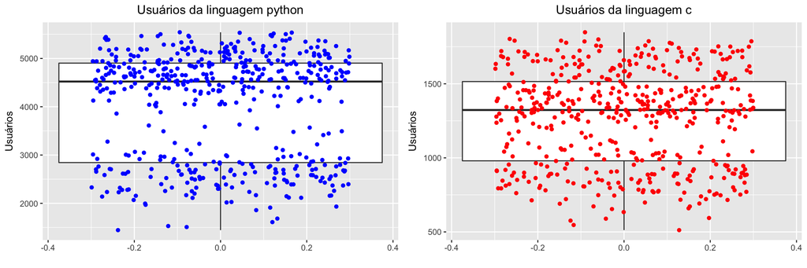

```r
plot_python <- dados_python %>%
  ggplot(aes(x = 0, y = usuarios)) +
  geom_boxplot() +
  geom_point(position = position_jitter(width = 0.3), color="blue") +
  ggtitle("Usuários da linguagem python") +
  labs(x = "", y = "Usuários")

plot_c <- dados_c %>%
  ggplot(aes(x = 0, y = usuarios)) +
  geom_boxplot() +
  geom_point(position = position_jitter(width = 0.3), color="red") +
  ggtitle("Usuários da linguagem c") +
  labs(x = "", y = "Usuários")

multiplot(plot_python, plot_c, cols = 2)
```

Pelo boxplot, podemos perceber que as duas linguagens apresentam medianas bem diferentes. Além disso, a distribução dos usuários não apresenta nenhum *outlier*. Por conta disso, não deu-se necessário a aplicação de métodos para tratar de pontos desse tipo.

Agora, quero analisar a densidade da distribuição dos usuários nas duas linguagens escolhidas:

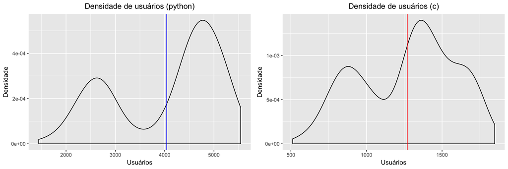

```r
plot_python <- dados_python %>%
  ggplot(aes(x=usuarios)) +
  geom_density() +
  geom_vline(xintercept = mean(dados_python$usuarios), color = "blue") +
  ggtitle("Densidade de usuários (python)") +
  labs(x = "Usuários", y = "Densidade")

plot_c <- dados_c %>%
  ggplot(aes(x=usuarios)) +
  geom_density() +
  geom_vline(xintercept = mean(dados_c$usuarios), color="red") +
  ggtitle("Densidade de usuários (c)") +
  labs(x = "Usuários", y = "Densidade")

multiplot(plot_python, plot_c, cols = 2)
```

Podemos perceber que **as duas linguagens apresentam distribuições bimodais**, onde a média de usuários (linhas verticais) se apresentam mais próxima do pico mais alto, como era de se esperar. Vamos entender mais à frente o porquê da distribuição bimodal.

A título de curiosidade, quero analisar a quantidade de usuários que editam arquivos mês-a-mês para cada linguagem:

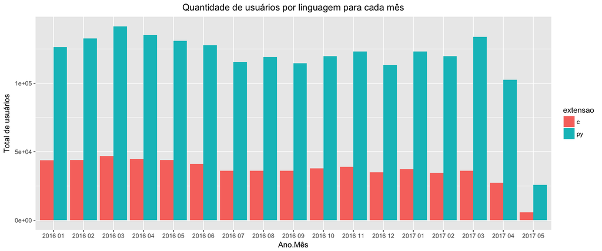

```r
dados_py_c <- dados_clean %>%
  filter(extensao == "py" | extensao == "c")

dados_py_c %>%
  group_by(extensao, ano, mes) %>%
  summarise(total = sum(usuarios)) %>%
  ggplot(aes(x = paste(ano, sprintf("%02d", mes)), y = total, fill = extensao)) +
  geom_bar(stat = "identity", position = "dodge") +
  ggtitle("Quantidade de usuários por linguagem para cada mês") +
  labs(x = "Ano.Mês", y = "Total de usuários")
```

Dando prosseguimento a atividade, quero analisar agora a distruibuição da quantidade de usuários por dia da semana:

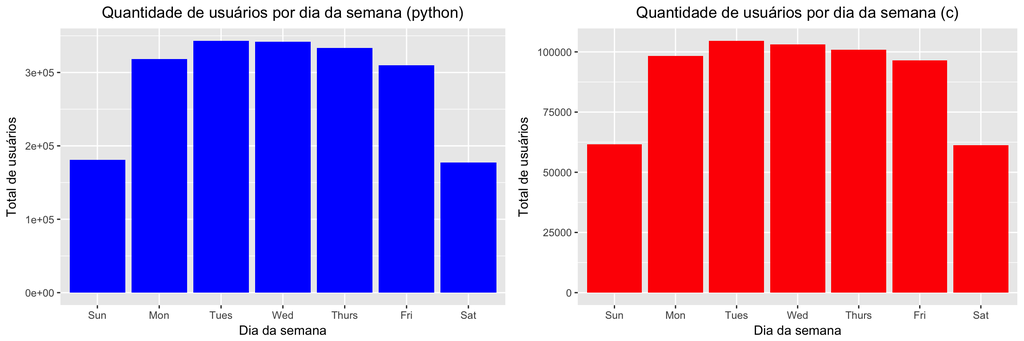

```r
plot_python <- dados_python %>%
  group_by(dia_da_semana) %>%
  summarise(total_usuarios = sum(usuarios)) %>%
  ggplot(aes(x = dia_da_semana, y = total_usuarios)) +
  geom_bar(stat = "identity", fill = "blue") +
  ggtitle("Quantidade de usuários por dia da semana (python)") +
  labs(x = "Dia da semana", y = "Total de usuários")

plot_c <- dados_c %>%
  group_by(dia_da_semana) %>%
  summarise(total_usuarios = sum(usuarios)) %>%
  ggplot(aes(x = dia_da_semana, y = total_usuarios)) +
  geom_bar(stat = "identity", fill = "red") +
  ggtitle("Quantidade de usuários por dia da semana (c)") +
  labs(x = "Dia da semana", y = "Total de usuários")

multiplot(plot_python, plot_c, cols = 2)
```

É possível perceber pelo gráfico que **ambas as linguagens apresentam maior atividade durante os dias da semana. Além disso, em ambas, o pico de produtividade é na terça-feira**. Esse gráfico também mostra o porque da distribuição bimodal vista anteriormente: há um pico para os dias da semana e outro para os dias do fim de semana.

Que tal visualizar o gráfico da distribuição dos pontos para cada dia da semana?

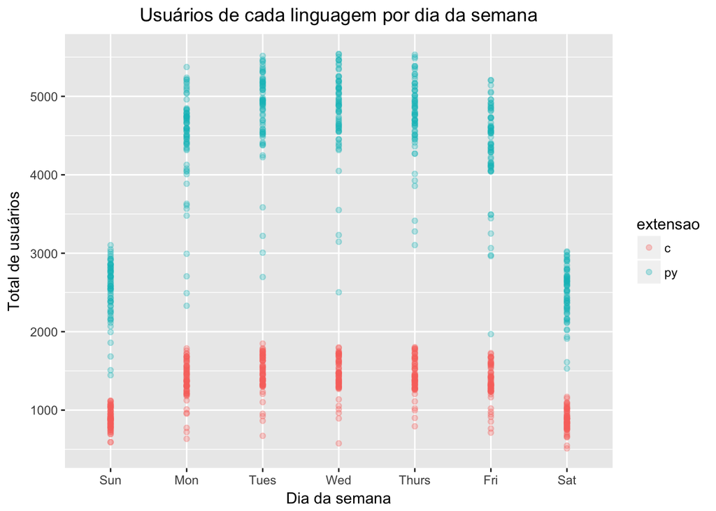

```r
dados_py_c %>%
  ggplot(aes(x = dia_da_semana, y = usuarios, color = extensao)) +
  geom_point(alpha = 0.3) +
  ggtitle("Usuários de cada linguagem por dia da semana") +
  labs(x = "Dia da semana", y = "Total de usuários")
```

Pelo gráfico acima, podemos perceber que **a quantidade de usuários que alteram arquivos python é sempre maior que a quantidade de usuários que alteram arquivos c em todos os dias da semana**. Infelizmente, não há nenhuma interseção dos pontos em nenhum dia da semana. Isso pode indicar que talvez exista uma diferença significativa entre as duas linguagens.

Também quero visualizar se a atividade durante os dias da semana é diferente dependendo do mês do ano:

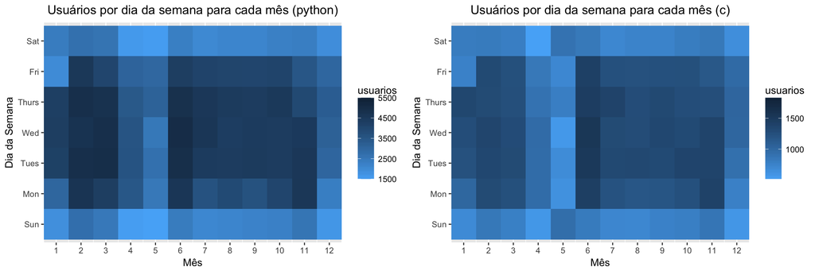

```r
plot_python <- dados_python %>%
  ggplot(aes(x = mes, y = dia_da_semana)) +
  geom_tile(aes(fill = usuarios)) +
  ggtitle("Usuários por dia da semana para cada mês (python)") +
  labs(x = "Mês", y = "Dia da Semana") +
  scale_fill_gradient(low = "#56B1F7", high = "#132B43") +
  scale_x_continuous(breaks = c(1:12), expand = c(0,0))

plot_c <- dados_c %>%
  ggplot(aes(x = mes, y = dia_da_semana)) +
  geom_tile(aes(fill = usuarios)) +
  ggtitle("Usuários por dia da semana para cada mês (c)") +
  labs(x = "Mês", y = "Dia da Semana") +
  scale_fill_gradient(low = "#56B1F7", high = "#132B43") +
  scale_x_continuous(breaks = c(1:12), expand = c(0,0))

multiplot(plot_python, plot_c, cols = 2)
```

Pelo gráfico acima, podemos ver que as duas linguagens apresentam comportamentos parecidos. Além disso, há alguns padrões interessantes:

- Em janeiro, há menos alterações de arquivos python e c nas sexta-feiras;
- Os meses de abril e maio também apresentam poucas edições de arquivo nas duas linguagens;
- Os meses de fevereiro e junho são os meses de maior atividade durante a semana;

Por fim, quero analisar a distribuição do número de usuários para os dias da semana e do fim de semana. Esses gráficos são importantes para a resposta das questões.

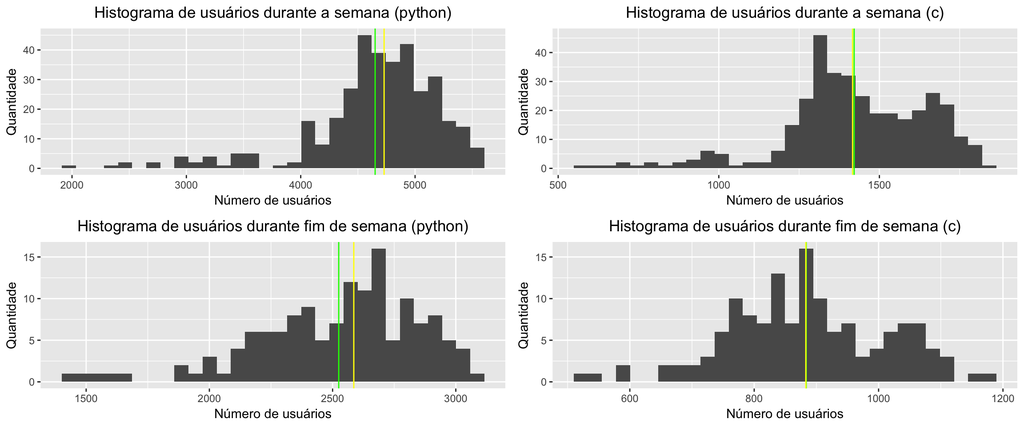

```r
dados_python_fds <- dados_python %>% filter(dia_da_semana == "Sat" | dia_da_semana == "Sun")
dados_python_dds <- dados_python %>% filter(dia_da_semana != "Sat" & dia_da_semana != "Sun")
dados_c_fds <- dados_c %>% filter(dia_da_semana == "Sat" | dia_da_semana == "Sun")
dados_c_dds <- dados_c %>% filter(dia_da_semana != "Sat" & dia_da_semana != "Sun")

plot_python_fds <- dados_python_fds %>%
  ggplot(aes(x = usuarios)) +
  geom_histogram(bins=30) +
  geom_vline(xintercept = mean(dados_python_fds$usuarios), color = "green") +
  geom_vline(xintercept = median(dados_python_fds$usuarios), color = "yellow") +
  ggtitle("Histograma de usuários durante fim de semana (python)") +
  labs(x = "Número de usuários", y = "Quantidade")

plot_python_dds <- dados_python_dds %>%
  ggplot(aes(x = usuarios)) +
  geom_histogram(bins=30) +
  geom_vline(xintercept = mean(dados_python_dds$usuarios), color = "green") +
  geom_vline(xintercept = median(dados_python_dds$usuarios), color = "yellow") +
  ggtitle("Histograma de usuários durante a semana (python)") +
  labs(x = "Número de usuários", y = "Quantidade")

plot_c_fds <- dados_c_fds %>%
  ggplot(aes(x = usuarios)) +
  geom_histogram(bins=30) +
  geom_vline(xintercept = mean(dados_c_fds$usuarios), color = "green") +
  geom_vline(xintercept = median(dados_c_fds$usuarios), color = "yellow") +
  ggtitle("Histograma de usuários durante fim de semana (c)") +
  labs(x = "Número de usuários", y = "Quantidade")

plot_c_dds <- dados_c_dds %>%
  ggplot(aes(x = usuarios)) +
  geom_histogram(bins=30) +
  geom_vline(xintercept = mean(dados_c_dds$usuarios), color = "green") +
  geom_vline(xintercept = median(dados_c_dds$usuarios), color = "yellow") +
  ggtitle("Histograma de usuários durante a semana (c)") +
  labs(x = "Número de usuários", y = "Quantidade")

multiplot(plot_python_dds, plot_python_fds, plot_c_dds, plot_c_fds, cols = 2)
```

Os gráficos acima nos mostram que **tanto a média quanto a mediana são próximas em todos os gráficos**. Logo, quando formos estimar a estatística da população na próxima seção, podemos usar qualquer uma delas, ao meu ver. Também é possível ver diferentes distribuições em cada gráfico, mas nenhuma delas aparenta ser muito próxima da normal.

Na próxima seção, vamos mostrar que, **independemente da distribuição original, a distribuição amostral se aproxima da distribuição normal quando utilizamos um processo de amostragem (no caso, será o *boostrap*)**.

# 3. Inferência Estatística

Como os dados que temos representam apenas uma amostra da população, teremos de efetuar o *bootstrap* para estimar estatísticas da população, calcular os intervalos de confiança e, consequentemente, compará-las. Neste trabalho vamos estimar a média da população.

Em ambas as respostas das questões, **vamos efetuar 4000 repetições de *bootstrap* e calcular o intervalo de confiança para 95%**.

## 3.1 Comparação da popularidade entre fim de semana e dias de semana para cada linguagem

A primeira inferência que vamos aplicar será para comparar a popularidade de cada linguagem durante a semana e durante o fim de semana. Nesse caso, queremos saber se, para cada linguagem, há uma diferença significativa entre a popularidade durante a semana e durante o fim de semana e quanto é essa diferença. Em outras palavras: **Será que a linguagem em questão é mais popular durante a semana do que durante o fim de semana? Se sim, quanto é essa diferença?**

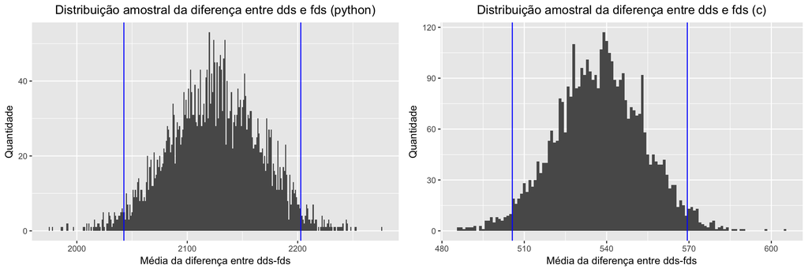

```r
mean.python <- bootstrap2(dados_python_dds, data2 = dados_python_fds, mean(usuarios), R = 4000, seed = 1234)
mean.c <- bootstrap2(dados_c_dds, data2 = dados_c_fds, mean(usuarios), R = 4000, seed = 1234)

ci.python <- mean.python %>% CI.percentile(probs = c(.025, .975))
ci.c <- mean.c %>% CI.percentile(probs = c(.025, .975))

plot_python <- mean.python$replicates %>%
  as.data.frame() %>%
  ggplot(aes(x = `mean(usuarios): dados_python_dds-dados_python_fds`)) +
  geom_histogram(binwidth = 1) +
  geom_vline(xintercept = as.vector(ci.python)[1], color = "blue") +
  geom_vline(xintercept = as.vector(ci.python)[2], color = "blue") +
  ggtitle("Distribuição amostral da diferença entre dds e fds (python)") +
  labs(x = "Média da diferença entre dds-fds", y = "Quantidade")

plot_c <- mean.c$replicates %>%
  as.data.frame() %>%
  ggplot(aes(x = `mean(usuarios): dados_c_dds-dados_c_fds`)) +
  geom_histogram(binwidth = 1) +
  geom_vline(xintercept = as.vector(ci.c)[1], color = "blue") +
  geom_vline(xintercept = as.vector(ci.c)[2], color = "blue") +
  ggtitle("Distribuição amostral da diferença entre dds e fds (c)") +
  labs(x = "Média da diferença entre dds-fds", y = "Quantidade")

multiplot(plot_python, plot_c, cols = 2)
```

```r
ci.python
```

```
##                                                       2.5%    97.5%
## mean(usuarios): dados_python_dds-dados_python_fds 2042.595 2202.787
```

```r
ci.c
```

```
##                                             2.5%    97.5%
## mean(usuarios): dados_c_dds-dados_c_fds 505.6382 569.3936
```

Ambos os intervalos de confiança estão destacados em azul no gráfico. **Vale ressaltar que os intervalos de confiança mostrados estimam a diferença média da população**.

Vamos agora observar os intervalos de confiança das duas linguagens:

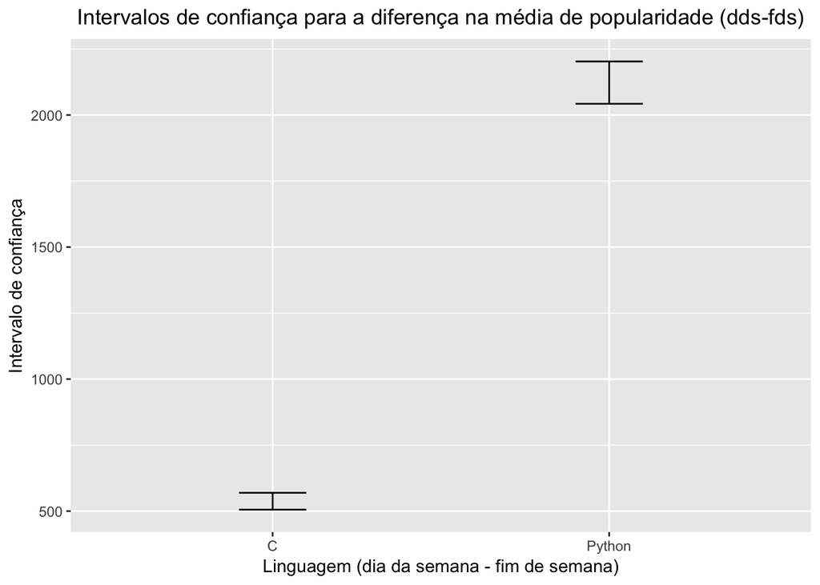

```r
df = data.frame(rbind(ci.python, ci.c), row.names = c("mean_diff_python", "mean_diff_c"))
df$medida = row.names(df)

df %>%
  ggplot(aes(x = medida, ymin = X2.5., ymax = X97.5.)) +
  geom_errorbar(width = .2) +
  ggtitle("Intervalos de confiança para a diferença na média de popularidade (dds-fds)") +
  labs(x = "Linguagem (dia da semana - fim de semana)", y = "Intervalo de confiança") +
  scale_x_discrete(labels = c("mean_diff_python"="Python", "mean_diff_c"="C"))
```

Pelo gráfico, que também há uma diferença significativa entre as duas linguagens (já que as barras de erro não se cruzam). No entanto, não podemos afirmar quanto é essa diferença.

## 3.2 Comparação da popularidade durante a semana entre as duas linguagens

Nessa seção, queremos saber agora se há uma diferença significativa de popularidade entre as duas linguagens quando comparamos a variação de popularidade durante os dias da semana. Para isso, vamos utilizar a mesma abordagem que na seção anterior, porém agora nossas amostra são representadas pelos dados das linguagens python e c (apenas dias de semana).

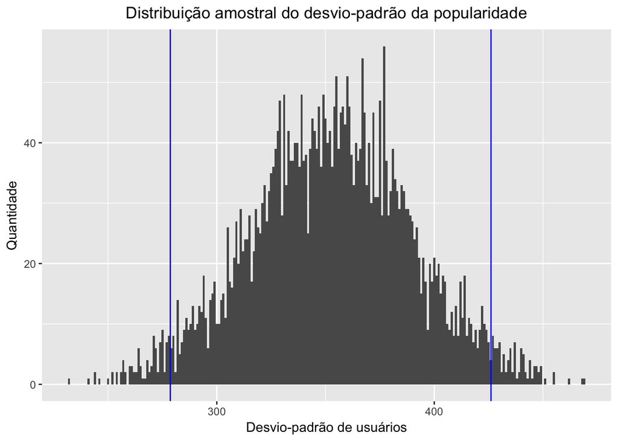

```r
mean.diff <- bootstrap2(dados_python_dds, data2 = dados_c_dds, sd(usuarios), R = 4000, seed = 1234)

ci.diff <- CI.percentile(mean.diff, probs = c(.025, .975))

mean.diff$replicates %>%
  as.data.frame() %>%
  ggplot(aes(x = `sd(usuarios): dados_python_dds-dados_c_dds`)) +
  geom_histogram(binwidth = 1) +
  geom_vline(xintercept = as.vector(ci.diff)[1], color = "blue") +
  geom_vline(xintercept = as.vector(ci.diff)[2], color = "blue") +
  ggtitle("Distribuição amostral do desvio-padrão da popularidade") +
  labs(x = "Desvio-padrão de usuários", y = "Quantidade")
```

```r
ci.diff
```

```
##                                                2.5%    97.5%
## sd(usuarios): dados_python_dds-dados_c_dds 278.6105 426.0932
```

Para finalizar, vamos plotar esse intervalo de confiança:

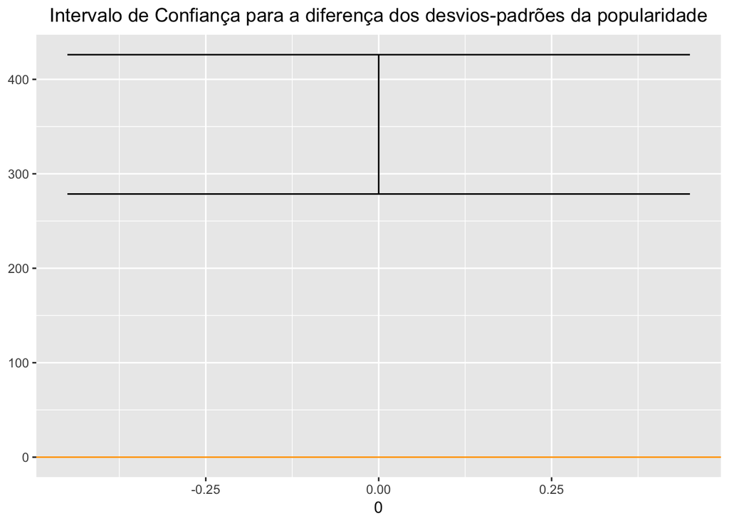

```r
ci.diff %>%
  as_data_frame() %>%
  ggplot(aes(x = 0, ymin = `2.5%`, ymax = `97.5%`)) +
  geom_errorbar() +
  geom_hline(yintercept = 0, color="orange")+
  ggtitle("Intervalo de Confiança para a diferença dos desvios-padrões da popularidade")
```

Pelo gráfico, podemos concluir que **há uma diferença significativa entre as popularidades da linguagem c e python, uma vez que o intervalo de confiança não cruza o valor zero**.

# 4. Conclusões

- O *bootstrap* se mostrou uma técnica eficiente para estimar os parâmetros da população. Quatro mil repetições foram efetuadas sobre as amostras ($n \approx 500$);
- Com 95% de confiança, há uma diferença significativa entre as popularidades das linguagens python e c durante a semana e durante os finais de semana;
- Há uma diferença significativa entre a variação de popularidade das linguagens python e c para um nível de confiança de 95%;